# Intrusion_Detection_System_KDD_Cup_Dataset_EDA

This notebook comprises of following things:

##### **Data Acquisition:** The KDD Cup 1999 dataset was downloaded using kagglehub.

##### **File Path Resolution:** Initially, a find_file function is implemented to recursively search the downloaded directory, resolving FileNotFoundError.

##### **Column Name Extraction:** Column names for the dataset were dynamically extracted from the kddcup.names file. we need to select after first line where the first line (attack types) can be mistaken for a column names, ensuring proper mapping.

##### **Data Loading and Initial Inspection:** The dataset was loaded into a Pandas DataFrame using the extracted column names. Initial checks confirmed the shape of the data and the absence of missing values.

##### **Feature Engineering and Preprocessing:**

1. ```
   An 'Attack Type' column was derived from the 'target' column, mapping specific attack names to broader categories (e.g., 'neptune' to 'dos').
   ```

2. ```
   Categorical features like protocol_type and flag were mapped to numerical values.
   ```

3. ```
   Highly correlated features and features with no variance (e.g., is_host_login, num_outbound_cmds) were identified and dropped to simplify the model and prevent multicollinearity.
   ```

4. ```
   The service column was dropped as it contained too many unique values for one-hot encoding without significant feature engineering.
   ```

5. ```
   The features were scaled using MinMaxScaler to normalize their ranges, which is crucial for many machine learning algorithms.
   ```

##### **Data Splitting:** The dataset is split into training (67%) and testing (33%) sets for model development and evaluation.

##### **Model Training and Evaluation:** Several classification models (**Naive Bayes, Decision Tree, Random Forest, SVM, Logistic Regression, Gradient Boosting**) were trained on the preprocessed data. Their training and testing accuracies, along with execution times, were calculated and displayed, showing generally high performance across the models for this dataset.

### Download KDD Cup 1999 Dataset from Kaggle

We will use `kagglehub` to download the dataset. Once downloaded, the files `kddcup.names.txt` and `kddcup.data_10_percent_corrected` will be available in the specified path.

```
Path to dataset files: /root/.cache/kagglehub/datasets/galaxyh/kdd-cup-1999-data/versions/1

--- Contents of downloaded dataset directory ---
1/
    kddcup.data_10_percent.gz
    kddcup.names
    kddcup.testdata.unlabeled.gz
    kddcup.data.gz
    kddcup.testdata.unlabeled_10_percent.gz
    typo-correction.txt
    kddcup.data.corrected
    kddcup.newtestdata_10_percent_unlabeled.gz
    kddcup.data_10_percent_corrected
    training_attack_types
    corrected.gz
    kddcup.data/
        kddcup.data
    kddcup.data_10_percent/
        kddcup.data_10_percent
    kddcup.newtestdata_10_percent_unlabeled/
        kddcup.newtestdata_10_percent_unlabeled
    corrected/
        corrected
    kddcup.testdata.unlabeled_10_percent/
        kddcup.testdata.unlabeled_10_percent
    kddcup.testdata.unlabeled/
        kddcup.testdata.unlabeled
----------------------------------------------
```

```
back,buffer_overflow,ftp_write,guess_passwd,imap,ipsweep,land,loadmodule,multihop,neptune,nmap,normal,perl,phf,pod,portsweep,rootkit,satan,smurf,spy,teardrop,warezclient,warezmaster.
duration: continuous.
protocol_type: symbolic.
service: symbolic.
flag: symbolic.
src_bytes: continuous.
dst_bytes: continuous.
land: symbolic.
wrong_fragment: continuous.
urgent: continuous.
hot: continuous.
num_failed_logins: continuous.
logged_in: symbolic.
num_compromised: continuous.
root_shell: continuous.
su_attempted: continuous.
num_root: continuous.
num_file_creations: continuous.
num_shells: continuous.
num_access_files: continuous.
num_outbound_cmds: continuous.
is_host_login: symbolic.
is_guest_login: symbolic.
count: continuous.
srv_count: continuous.
serror_rate: continuous.
srv_serror_rate: continuous.
rerror_rate: continuous.
srv_rerror_rate: continuous.
same_srv_rate: continuous.
diff_srv_rate: continuous.
srv_diff_host_rate: continuous.
dst_host_count: continuous.
dst_host_srv_count: continuous.
dst_host_same_srv_rate: continuous.
dst_host_diff_srv_rate: continuous.
dst_host_same_src_port_rate: continuous.
dst_host_srv_diff_host_rate: continuous.
dst_host_serror_rate: continuous.
dst_host_srv_serror_rate: continuous.
dst_host_rerror_rate: continuous.
dst_host_srv_rerror_rate: continuous.
```

```
Number of columns extracted: 42
```

'training_attack_types.txt' is not directly present in the downloaded dataset, and we need to create dictionary for attack _types.

A connection is a sequence of TCP packets starting and ending at some well defined times, between which data flows to and from a source IP address to a target IP address under some well defined protocol. Each connection is labeled as either normal, or as an attack, with exactly one specific attack type. Each connection record consists of about 100 bytes.

Attacks fall into four main categories:

##### **DOS:** denial-of-service, e.g. syn flood.

##### **R2L:** unauthorized access from a remote machine, e.g., guessing password.

##### **U2R:** unauthorized access to administrative level /local superuser /root privileges, e.g., various ``buffer overflow'' attacks.

##### **probing:** surveillance and other probing, e.g., port scanning.

> For more info https://kdd.ics.uci.edu/databases/kddcup99/task.html

|  | duration | protocol_type | service | flag | src_bytes | dst_bytes | land | wrong_fragment | urgent | hot | ... | dst_host_same_srv_rate | dst_host_diff_srv_rate | dst_host_same_src_port_rate | dst_host_srv_diff_host_rate | dst_host_serror_rate | dst_host_srv_serror_rate | dst_host_rerror_rate | dst_host_srv_rerror_rate | target | Attack Type |
| --- | --- | --- | --- | --- | --- | --- | --- | --- | --- | --- | --- | --- | --- | --- | --- | --- | --- | --- | --- | --- | --- |
| 367759 | 0 | tcp | ssh | S0 | 0 | 0 | 0 | 0 | 0 | 0 | ... | 0.05 | 0.06 | 0.0 | 0.0 | 1.0 | 1.0 | 0.0 | 0.0 | neptune. | dos |
| 132802 | 0 | icmp | ecr_i | SF | 1032 | 0 | 0 | 0 | 0 | 0 | ... | 1.00 | 0.00 | 1.0 | 0.0 | 0.0 | 0.0 | 0.0 | 0.0 | smurf. | dos |
| 435274 | 0 | icmp | ecr_i | SF | 520 | 0 | 0 | 0 | 0 | 0 | ... | 1.00 | 0.00 | 1.0 | 0.0 | 0.0 | 0.0 | 0.0 | 0.0 | smurf. | dos |
| 158439 | 0 | icmp | ecr_i | SF | 1032 | 0 | 0 | 0 | 0 | 0 | ... | 1.00 | 0.00 | 1.0 | 0.0 | 0.0 | 0.0 | 0.0 | 0.0 | smurf. | dos |
| 258181 | 0 | icmp | ecr_i | SF | 1032 | 0 | 0 | 0 | 0 | 0 | ... | 1.00 | 0.00 | 1.0 | 0.0 | 0.0 | 0.0 | 0.0 | 0.0 | smurf. | dos |

5 rows × 43 columns

```
(494021, 43)
```

|  | 0 |
| --- | --- |
| duration | 0 |
| protocol_type | 0 |
| service | 0 |
| flag | 0 |
| src_bytes | 0 |
| dst_bytes | 0 |
| land | 0 |
| wrong_fragment | 0 |
| urgent | 0 |
| hot | 0 |
| num_failed_logins | 0 |
| logged_in | 0 |
| num_compromised | 0 |
| root_shell | 0 |
| su_attempted | 0 |
| num_root | 0 |
| num_file_creations | 0 |
| num_shells | 0 |
| num_access_files | 0 |
| num_outbound_cmds | 0 |
| is_host_login | 0 |
| is_guest_login | 0 |
| count | 0 |
| srv_count | 0 |
| serror_rate | 0 |
| srv_serror_rate | 0 |
| rerror_rate | 0 |
| srv_rerror_rate | 0 |
| same_srv_rate | 0 |
| diff_srv_rate | 0 |
| srv_diff_host_rate | 0 |
| dst_host_count | 0 |
| dst_host_srv_count | 0 |
| dst_host_same_srv_rate | 0 |
| dst_host_diff_srv_rate | 0 |
| dst_host_same_src_port_rate | 0 |
| dst_host_srv_diff_host_rate | 0 |
| dst_host_serror_rate | 0 |
| dst_host_srv_serror_rate | 0 |
| dst_host_rerror_rate | 0 |
| dst_host_srv_rerror_rate | 0 |
| target | 0 |
| Attack Type | 0 |

**dtype:** int64

```
['flag', 'protocol_type', 'service']
```

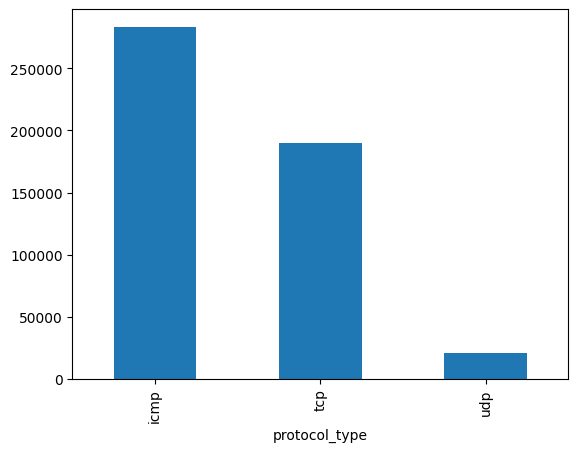

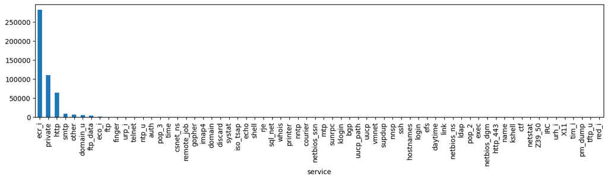

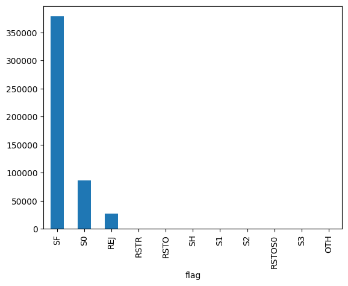

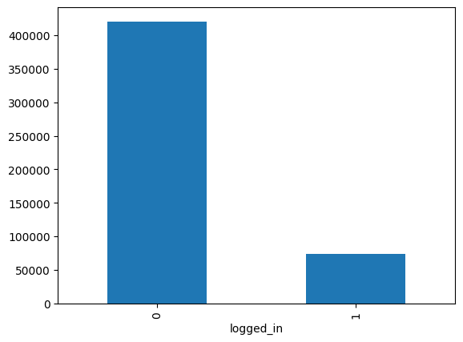

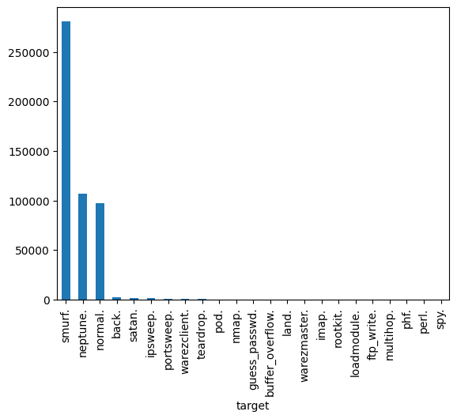

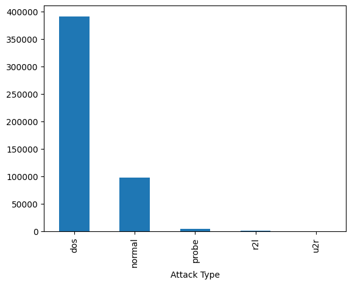

```
Index(['duration', 'protocol_type', 'service', 'flag', 'src_bytes',
       'dst_bytes', 'land', 'wrong_fragment', 'urgent', 'hot',
       'num_failed_logins', 'logged_in', 'num_compromised', 'root_shell',
       'su_attempted', 'num_root', 'num_file_creations', 'num_shells',
       'num_access_files', 'num_outbound_cmds', 'is_host_login',
       'is_guest_login', 'count', 'srv_count', 'serror_rate',
       'srv_serror_rate', 'rerror_rate', 'srv_rerror_rate', 'same_srv_rate',
       'diff_srv_rate', 'srv_diff_host_rate', 'dst_host_count',
       'dst_host_srv_count', 'dst_host_same_srv_rate',
       'dst_host_diff_srv_rate', 'dst_host_same_src_port_rate',
       'dst_host_srv_diff_host_rate', 'dst_host_serror_rate',
       'dst_host_srv_serror_rate', 'dst_host_rerror_rate',
       'dst_host_srv_rerror_rate', 'target', 'Attack Type'],
      dtype='object')
```

```
Shape of X_train: (330994, 41), X_test: (163027, 41)
Shape of y_train: (330994, 1), y_test: (163027, 1)
```

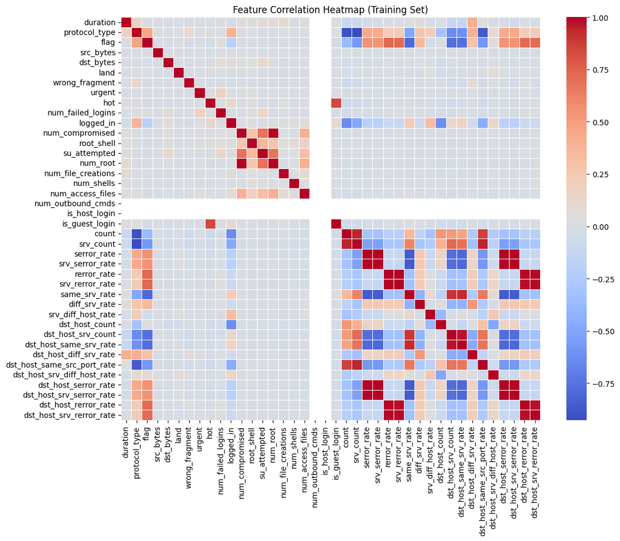

```
is_host_login        1
num_outbound_cmds    1
dtype: int64
```

```
Shape of X_train after dropping correlated columns: (330994, 31)
Shape of X_test after dropping correlated columns: (163027, 31)
```

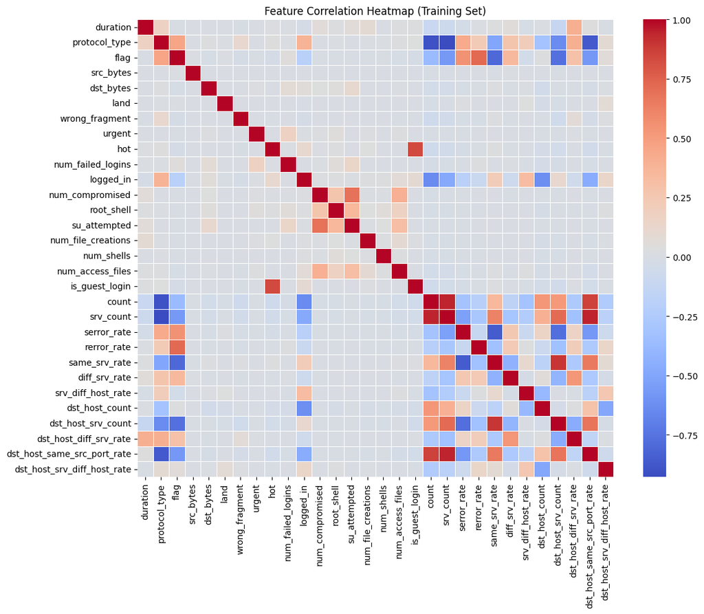

|  | duration | protocol_type | flag | src_bytes | dst_bytes | land | wrong_fragment | urgent | hot | num_failed_logins | ... | serror_rate | rerror_rate | same_srv_rate | diff_srv_rate | srv_diff_host_rate | dst_host_count | dst_host_srv_count | dst_host_diff_srv_rate | dst_host_same_src_port_rate | dst_host_srv_diff_host_rate |
| --- | --- | --- | --- | --- | --- | --- | --- | --- | --- | --- | --- | --- | --- | --- | --- | --- | --- | --- | --- | --- | --- |
| 482186 | 1470 | 2 | 0 | 147 | 105 | 0 | 0 | 0 | 0 | 0 | ... | 0.0 | 0.0 | 1.0 | 0.0 | 0.0 | 255 | 1 | 0.82 | 1.00 | 0.00 |
| 302290 | 0 | 0 | 0 | 1032 | 0 | 0 | 0 | 0 | 0 | 0 | ... | 0.0 | 0.0 | 1.0 | 0.0 | 0.0 | 255 | 255 | 0.00 | 1.00 | 0.00 |
| 9330 | 0 | 0 | 0 | 1032 | 0 | 0 | 0 | 0 | 0 | 0 | ... | 0.0 | 0.0 | 1.0 | 0.0 | 0.0 | 255 | 255 | 0.00 | 1.00 | 0.00 |
| 91417 | 6 | 1 | 0 | 2872 | 335 | 0 | 0 | 0 | 0 | 0 | ... | 0.0 | 0.0 | 1.0 | 0.0 | 0.0 | 188 | 186 | 0.02 | 0.01 | 0.01 |
| 293169 | 0 | 0 | 0 | 1032 | 0 | 0 | 0 | 0 | 0 | 0 | ... | 0.0 | 0.0 | 1.0 | 0.0 | 0.0 | 255 | 255 | 0.00 | 1.00 | 0.00 |

5 rows × 30 columns

```
Shape of X_train after scaling: (330994, 30)
Shape of X_test after scaling: (163027, 30)
```

### Modelling

```
Training Naive Bayes...
Naive Bayes - Train Accuracy: 87.95%, Test Accuracy: 87.90%
Training Time: 0.4925s, Testing Time: 0.5021s

Training Decision Tree...
Decision Tree - Train Accuracy: 99.39%, Test Accuracy: 99.38%
Training Time: 1.0032s, Testing Time: 0.0631s

Training Random Forest...
Random Forest - Train Accuracy: 100.00%, Test Accuracy: 99.97%
Training Time: 5.2934s, Testing Time: 0.6529s

Training SVM...
SVM - Train Accuracy: 99.88%, Test Accuracy: 99.88%
Training Time: 117.2052s, Testing Time: 152.0973s

Training Logistic Regression...
Logistic Regression - Train Accuracy: 99.36%, Test Accuracy: 99.36%
Training Time: 8.7182s, Testing Time: 0.0808s

Training Gradient Boosting...
Gradient Boosting - Train Accuracy: 99.91%, Test Accuracy: 99.91%
Training Time: 169.2220s, Testing Time: 2.6748s
```